# Final Project on Social Media Effects on Mental Health

Aarju Sapkota

**Introduction: Exploring the Impact of Social Media on Mental Health**

In my final project, I have decided to visualize the intricate relationship between social media usage and mental health, seeking to unravel the various factors that contribute to the well-being of individuals in the digital age. I have used two datasets that were available in Kaggle as https://www.kaggle.com/datasets/souvikahmed071/social-media-and-mental-health and https://www.kaggle.com/datasets/ngugimacharia/mental-health-and-social-media and made necessary adjustments so that it can be easily accessible and read into R in R studio. These datasets was originally collected for a data science and machine learning project that aimed at investigating the potential correlation between the amount of time an individual spends on social media and the impact it has on their mental health which was exactly what I wanted to visualize here. These datasets under examination encapsulates a comprehensive set of variables, ranging from demographic details such as age, gender, and occupation status, to nuanced aspects like affiliation with organizations, self-reported mental health status, and usage patterns. Exploring these dimensions allows us to discern patterns and trends that may shed light on the complex interplay between online activities and mental well-being.

## Load Package

Initially I just loaded the library that we used in class; however, R made me load other library packages like airports and cherryblossom, while I was trying to read the datasets. I actually do not have depth knowledge of where and how these libraries were used exactly.

```r
library(tidyverse)
library(airports)
library(cherryblossom)
library(usdata)
library(openintro)
library(readxl)
```

```r
SMandMH<-read.csv("SMMandH.csv")
```

```r
DBMHS2022<-read_excel("DBMHS2022.xlsx")
```

```
## Defaulting to continuous.
```

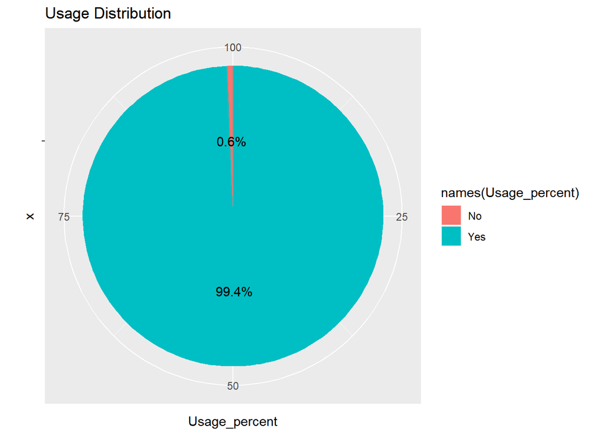

```r
 #Calculate the percentage of each category
Usage_percent <- prop.table(table(SMandMH$Usage)) * 100

# Create a pie chart with percentages using ggplot2
ggplot(data = NULL, aes(x = "", y = Usage_percent, fill = names(Usage_percent))) +
  geom_bar(width = 1, stat = "identity") +
  coord_polar("y", start = 0) +
  labs(title = "Usage Distribution", ) +
  geom_text(aes(label = paste0(round(Usage_percent, 1), "%")),
            position = position_stack(vjust = 0.5))
```

The data-set had 481 respondents and the visualization would be more accurate if most of them used social media, so I wanted to see what percentage of people surveyed actually used social media before understanding different other aspects different aspects, like for how long, and how it has affect in mental well being.It turned out that 99.4% respondents used social media, and only 0.6% did not use it.

Since the data_frame, SMandMH, had so many variables, and I was not concerned about all of them, so I tidy the data using select function and called it SM_MH as below :

```r
SM_MH <- SMandMH %>%
  select(Age, Gender, Relationship_Status, Occupation_Status, Affiliated_Organization, Usage, Platform, Average_Time, No_Purpose_Use, Distraction_Level, Worrying_Level, Depressed_or_down, Sleeping_Difficulty, Seeking_Validation )
glimpse(SM_MH)
```

```
## Rows: 481
## Columns: 14
## $ Age                     <dbl> 21, 21, 21, 21, 21, 22, 21, 21, 21, 20, 24, 21…
## $ Gender                  <chr> "Male", "Female", "Female", "Female", "Female"…
## $ Relationship_Status     <chr> "In a relationship", "Single", "Single", "Sing…
## $ Occupation_Status       <chr> "University Student", "University Student", "U…
## $ Affiliated_Organization <chr> "University", "University", "University", "Uni…
## $ Usage                   <chr> "Yes", "Yes", "Yes", "Yes", "Yes", "Yes", "Yes…
## $ Platform                <chr> "Facebook, Twitter, Instagram, YouTube, Discor…
## $ Average_Time            <chr> "Between 2 and 3 hours", "More than 5 hours", …
## $ No_Purpose_Use          <int> 5, 4, 3, 4, 3, 4, 4, 5, 5, 1, 5, 4, 3, 5, 5, 3…
## $ Distraction_Level       <int> 3, 3, 2, 2, 5, 4, 3, 2, 2, 1, 5, 4, 4, 3, 5, 4…
## $ Worrying_Level          <int> 2, 5, 5, 5, 5, 4, 4, 3, 1, 1, 3, 3, 4, 4, 5, 4…
## $ Depressed_or_down       <int> 5, 5, 4, 4, 4, 3, 5, 5, 5, 1, 5, 3, 3, 3, 5, 3…
## $ Sleeping_Difficulty     <int> 5, 5, 5, 2, 1, 4, 3, 1, 1, 1, 5, 2, 5, 3, 5, 2…
## $ Seeking_Validation      <int> 2, 1, 1, 2, 3, 3, 4, 1, 1, 1, 3, 3, 1, 2, 5, 2…
```

```r
Anxiety<-SM_MH %>%
  mutate(Anxiety = Depressed_or_down + Sleeping_Difficulty + Worrying_Level) %>%
  filter(
    Anxiety >= 8
    ) %>%
  select(Anxiety, Depressed_or_down, Sleeping_Difficulty, Worrying_Level)
```

```r
People<-nrow(Anxiety)
People
```

```
## [1] 383
```

```r
DBMHS2022<-read_excel("DBMHS2022.xlsx")
```

I want to tidy the data so I can use only the variables that interests me

```r
DBMHS<-DBMHS2022%>%
  select(Age,Gender,Frequency_Social_Media_Interaction,Self_reported_Mental_Health_Status,
Impact_on_Mental_Health_Score)
glimpse(DBMHS)
```

```
## Rows: 300
## Columns: 5
## $ Age                                <dbl> 28, 35, 22, 45, 29, 38, 24, 31, 50,…
## $ Gender                             <chr> "Female", "Male", "Female", "Male",…
## $ Frequency_Social_Media_Interaction <chr> "Frequently", "Occasionally", "Very…
## $ Self_reported_Mental_Health_Status <chr> "Good", "Excellent", "Poor", "Good"…
## $ Impact_on_Mental_Health_Score      <dbl> 3.5, 4.2, 2.1, 4.0, 3.1, 4.3, 2.0, …
```

Then I wanted to see if people use social media without any purpose or not and if yes let’s see what effects it has in mental well being of an individual.

```r
SM_MH <- SM_MH %>%
  group_by(No_Purpose_Use) %>%
  summarise(rating_counts = n())
print(SM_MH)
```

```
## # A tibble: 5 × 2
##   No_Purpose_Use rating_counts
##            <int>         <int>
## 1              1            20
## 2              2            65
## 3              3           129
## 4              4           163
## 5              5           104
```

```r
SM<-SMandMH%>%
select( Age, Gender, Occupation_Status, Relationship_Status, Average_Time, Platform)
```

```r
DB<-DBMHS2022%>%
select(Age, Gender, Frequency_Social_Media_Interaction, Self_reported_Mental_Health_Status,
Impact_on_Mental_Health_Score)
```

```r
SM_MH_DBMHS<-SM %>%
  left_join(DB)
```

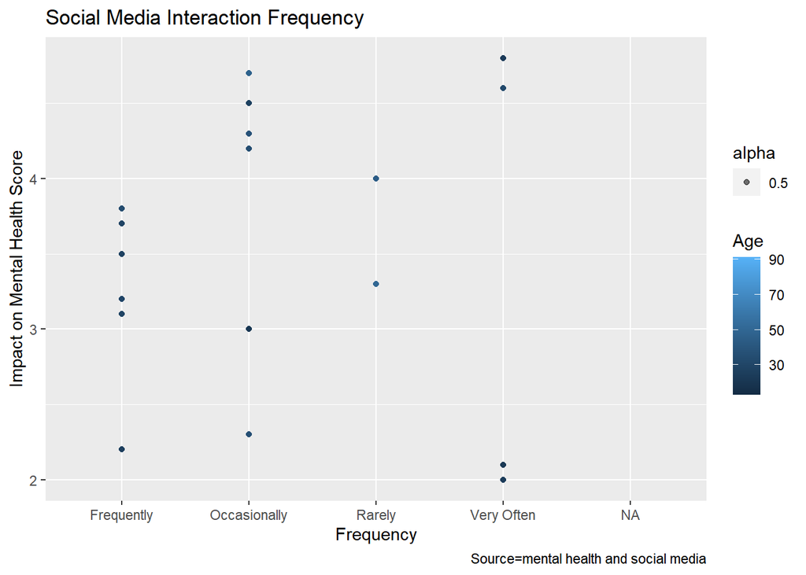

```r
ggplot(SM_MH_DBMHS, aes(x = Frequency_Social_Media_Interaction, y=Impact_on_Mental_Health_Score, color= Age, alpha=0.5)) +
  geom_point() +
  labs(title = "Social Media Interaction Frequency",
       x = "Frequency",
       y = "Impact on Mental Health Score",
       caption="Source=mental health and social media")
```

In order to visualize different aspects on Mental health from both of the datasets, I’m left joining dataset SMandM and dataframe DBMHS. I wanted to left join the dataframe SM_MH with DBMHS , but for some reasons it kept saying errors, so I had to use the first datase as a whole.

```r
SM<-SMandMH%>%
select( Age, Gender, Occupation_Status, Relationship_Status, Average_Time, Platform, No_Purpose_Use)
```

```r
DB<-DBMHS2022%>%
select(Age, Gender, Frequency_Social_Media_Interaction, Self_reported_Mental_Health_Status,
Impact_on_Mental_Health_Score)
```

```r
SM_MH_DBMHS <-SM %>%
  left_join(DB)
```

Then I wanted to see if people use social media without any purpose or not and if yes let’s see what effects it has in mental well being of an individual.

```r
SM_MH <- SM_MH %>%
  group_by(No_Purpose_Use) %>%
  summarise(rating_counts = n())
print(SM_MH)
```

```
## # A tibble: 5 × 2
##   No_Purpose_Use rating_counts
##            <int>         <int>
## 1              1             1
## 2              2             1
## 3              3             1
## 4              4             1
## 5              5             1
```

Then I wanted to see which platform was used most, so I can visualize where do people spend most time without any purpose,

```r
Platform_counts <- table(SM_MH_DBMHS$Platform)
most_used_Platform <- names(Platform_counts)[which.max(Platform_counts)]


print(most_used_Platform)
```

```
## [1] "Facebook, Instagram, YouTube, Snapchat"
```

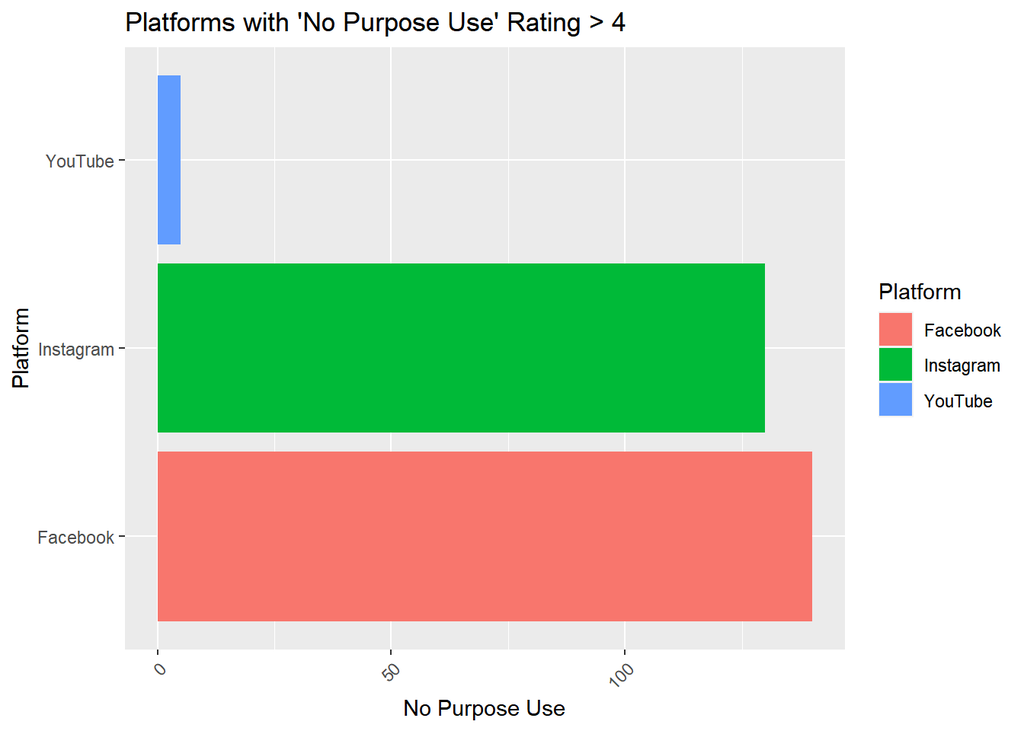

```r
filtered_data <- subset(SM_MH_DBMHS, Platform %in% c("Facebook", "Instagram", "YouTube"))


filtered_data <- subset(filtered_data, No_Purpose_Use > 4)

ggplot(filtered_data, aes(x = No_Purpose_Use, y = Platform, fill = Platform)) +
  geom_bar(stat = "identity") +
  labs(title = "Platforms with 'No Purpose Use' Rating > 4",
       x = "No Purpose Use",
       y = "Platform",
       fill = "Platform") +
  theme(axis.text.x = element_text(angle = 45, hjust = 1))
```

It is clear that people spend most time in Fcebook withoout any specific purpose followed by Instagram, but the number of people using Youtube with no purpose is very low.

#How about the relationship status, Occupation_Status, Age and Gender are related in terms of social media use and mental health

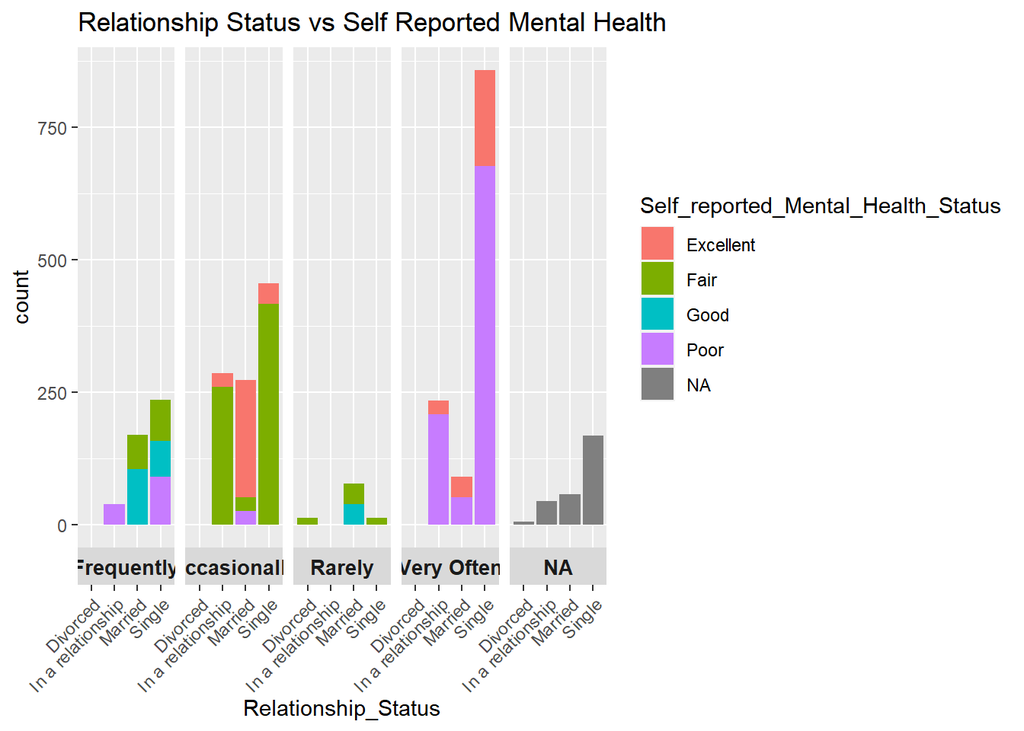

```r
ggplot(SM_MH_DBMHS, aes(x = Relationship_Status, fill = Self_reported_Mental_Health_Status)) +
  geom_bar() +
  facet_wrap(~Frequency_Social_Media_Interaction, strip.position = "bottom", nrow = 1) +
  labs(title="Relationship Status vs Self Reported Mental Health")+
  theme(axis.text.x = element_text(angle = 45, hjust = 1),
        strip.text = element_text(size = 10, face = "bold"))
```

Above visualization shows that irrespective of relationship status, but mostly single people, who interact very often through social media reported their mental health status as poor.

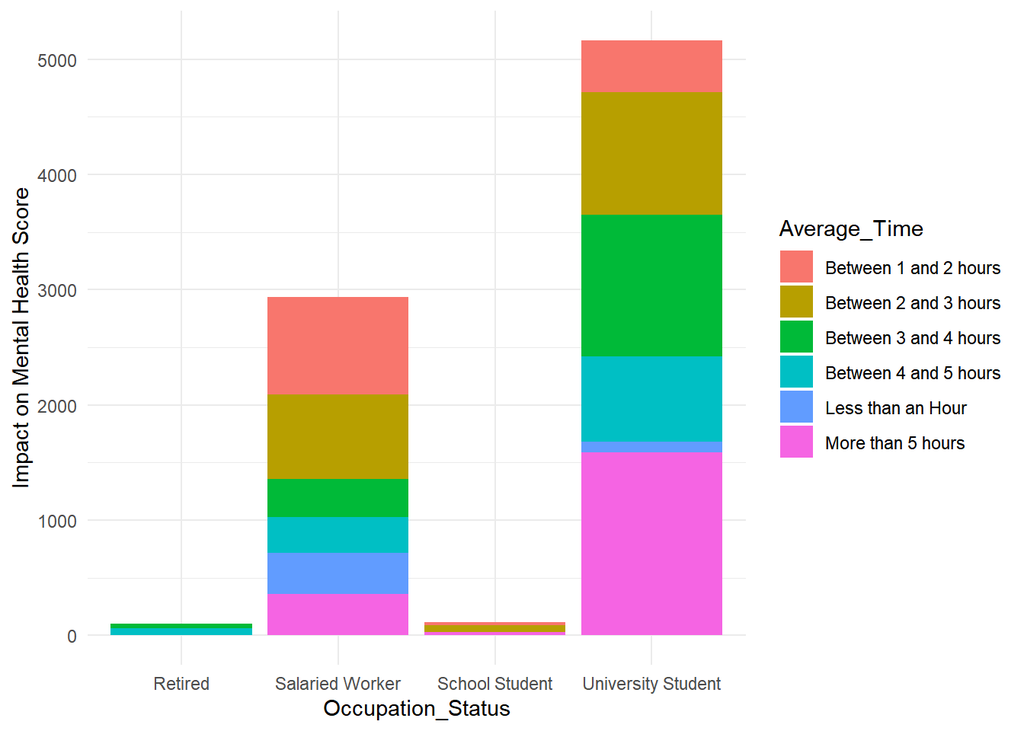

```r
ggplot(SM_MH_DBMHS , aes(x = Occupation_Status, y = Impact_on_Mental_Health_Score, fill=Average_Time)) +
  geom_col() +
  labs(x = "Occupation_Status", y = "Impact on Mental Health Score") +
  theme_minimal()
```

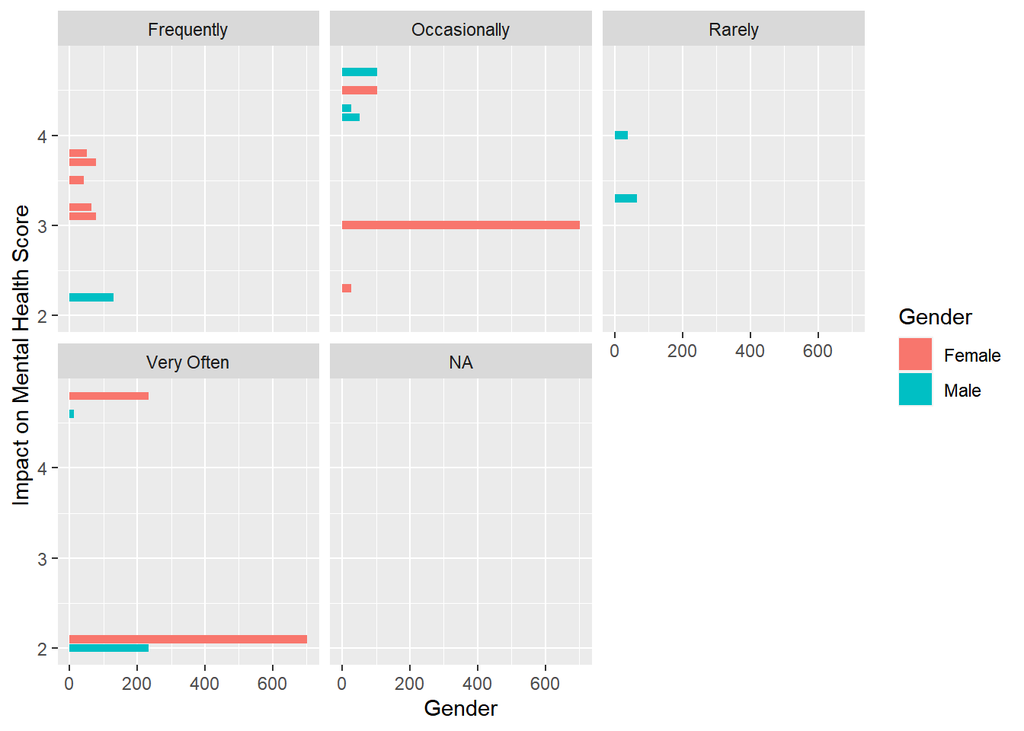

```r
ggplot(SM_MH_DBMHS, aes( y = Impact_on_Mental_Health_Score, fill=Gender)) +
  geom_bar() +
  facet_wrap(~Frequency_Social_Media_Interaction ) +
  labs(x = "Gender", y = "Impact on Mental Health Score")
```